# Group Assignment 1 Report

Group 2: Cai Anqi, Chan Yu Hang, Chin Synn Khee Joash, Chua Cheng Ling, Chua Hua Ren, Clarence Ong

## 1. Introduction

This report documents our analysis of consumers’ spending habits over the last 3 years in Malaysia. We are provided with 3 datasets, namely `DSA3101_Hackathon_Categories_Information.csv`, `DSA3101_Hackathon_Data.csv` and `DSA3101_Hackathon_Panelists_Demographics.csv`.

## 2. Exploratory Data Analysis (EDA)

### 2.1. Preview of each dataset

#### `DSA3101_Hackathon_Categories_Information.csv` - 62 rows, 3 columns

The first 6 rows is as follows:

| Category | Calories/100g | Price per Volume |
| --- | --- | --- |
| Baby Cereal | 188 | 29.41 |
| Beer | 43 | 15.12 |
| Belacan | 563 | 39.47 |
| Bird Nest | 46 | 73.45 |
| Biscuits | 416 | 15.57 |
| Bouilon | 16 | 29.09 |

The 62 categories are Baby Cereal, Beer, Belacan, Bird Nest, Biscuits, Bouilon, Butter, Cake, Canned Product, Cereal Beverage, Cereals, Cheese, Chicken Essence, Choc/Nut Spread, Chocolate, Coconut Milk, Coffee, Condensed/Evap Milk, Confectionery, Cooking Oils, Cooking Sauces, Cordials, Creamer, CSD, Cultured Milk, Drinking Water, Eggs, Energy Drinks, Flour, Frozen Food, Fruit/Veg Juices, Ghee, Honey, Ice Cream, Instant Noodles, Instant Soup, Isotonic Drinks, Jam, Kaya, Liquid Milk, Margarine, Milk Powder-Adult, Milk Powder-Infant, Milk Powder-Kids, MSG, Peanut Butter, Rice, RTD Coffee, RTD Tea, Salad Dressing, Savoury Spread, Seasoning Powder, Snack, Soy Milk, Spagetti, Spirits, Sugar, Tea, Tonic Food Drink, Wine, Yoghurt Drink, Yoghurts.

The summary statistics is shown below:

|  | Calories/100g | Price per Volume |
| --- | --- | --- |
|  | Min. : 0.0 | Min. : 0.370 |
|  | 1st Qu.: 61.0 | 1st Qu.: 7.513 |
|  | Median :210.5 | Median : 15.390 |
|  | Mean :243.8 | Mean : 23.895 |
|  | 3rd Qu.:377.2 | 3rd Qu.: 31.957 |
|  | Max. :800.0 | Max. :200.890 |

Cross-referencing with other sources, we found that the zero calories (MSG and Drinking Water) is indeed true.

#### `DSA3101_Hackathon_Data.csv` - 1318024 rows, 6 columns

The first 6 rows is as follows:

| Panel ID | Date | Category | Pack Size | Volume | Spend |
| --- | --- | --- | --- | --- | --- |
| Panel 101011101 | 2017-07-02 | CSD | 1 | 1.5 | 1.5 |
| Panel 101011101 | 2017-07-02 | Soy Milk | 1 | 1.0 | 2.8 |
| Panel 101011101 | 2017-07-02 | Cooking Sauces | 1 | 0.3 | 3.2 |
| Panel 101011101 | 2017-07-02 | Coconut Milk | 2 | 0.4 | 5.3 |
| Panel 101011101 | 2017-07-02 | Chocolate | 1 | 0.2 | 6.6 |
| Panel 101011101 | 2017-07-02 | Cooking Sauces | 1 | 0.3 | 5.0 |

This dataset consists of 156 Sundays (3 full years) which spans from 2017-06-25 to 2020-06-14.

The summary statistics is shown below:

|  | Pack Size | Volume | Spend |
| --- | --- | --- | --- |
|  | Min. : 0.000 | Min. : 0.000 | Min. : 0.000 |
|  | 1st Qu.: 1.000 | 1st Qu.: 0.300 | 1st Qu.: 3.500 |
|  | Median : 1.000 | Median : 0.800 | Median : 5.700 |
|  | Mean : 1.518 | Mean : 3.209 | Mean : 9.661 |
|  | 3rd Qu.: 2.000 | 3rd Qu.: 2.000 | 3rd Qu.: 10.800 |
|  | Max. :285.000 | Max. :600.000 | Max. :1664.000 |

There are entries with value zero in the 3 numerical columns. It could possibly be due to rounding errors (as the values are rounded to nearest 1 decimal place) or simply a mistake in recording.

#### `DSA3101_Hackathon_Panelists_Demographics.csv` - 4026 rows, 8 columns

The first 6 rows is as follows:

| ID | BMI | Income | Ethnicity | Lifestage | Strata | #HH | location |
| --- | --- | --- | --- | --- | --- | --- | --- |
| Panel 101011101 | Obese | Income 1500 - 1999 | North Malay | Empty Nesters | Urban | 1-3 Member HH | North |
| Panel 101016101 | Healthy | Income 1500 - 1999 | North Malay | Teens Aches | Urban | 1-3 Member HH | North |
| Panel 101019101 | Obese | Income < 1500 | North Malay | Teens Aches | Urban | 4 Member HH | North |
| Panel 101024101 | Over Weight | Income 1500 - 1999 | North Chinese | Nesting Families | Urban | 1-3 Member HH | North |
| Panel 105009103 | Over Weight | Income < 1500 | North Malay | Empty Nesters | Rural | 1-3 Member HH | North |
| Panel 105015101 | Healthy | Income 2000 - 2999 | North Malay | Teens and Toddlers | Rural | 7+ Member HH | North |

|  | Freq |
| --- | --- |
| Healthy | 1243 |
| Not Available | 790 |
| Obese | 449 |
| Over Weight | 796 |
| Under Weight | 748 |

|  | Freq |
| --- | --- |
| Income < 1500 | 580 |
| Income >5000 | 1071 |
| Income 1500 - 1999 | 456 |
| Income 2000 - 2999 | 824 |
| Income 3000 - 3999 | 673 |
| Income 4000 - 4999 | 422 |

|  | Freq |
| --- | --- |
| Central Chinese | 463 |
| Central Malay | 844 |
| Central Others | 160 |
| East Coast Chinese | 52 |
| East Coast Malay | 709 |
| East Coast Others | 18 |
| North Chinese | 275 |
| North Malay | 707 |
| North Others | 108 |
| South Chinese | 188 |
| South Malay | 438 |
| South Others | 64 |

|  | Freq |
| --- | --- |
| Empty Nesters | 272 |
| Matured Families | 648 |
| Nesting Families | 980 |
| Teens Aches | 930 |
| Teens and Toddlers | 1061 |
| Yankys | 135 |

|  | Freq |
| --- | --- |
| Rural | 715 |
| Urban | 3311 |

|  | Freq |
| --- | --- |
| 1-3 Member HH | 1107 |
| 4 Member HH | 925 |
| 5 Member HH | 904 |
| 6 Member HH | 546 |
| 7+ Member HH | 544 |

|  | Freq |
| --- | --- |
| Central | 1467 |
| East Coast | 779 |
| North | 1090 |
| South | 690 |

### 2.2. Background Information

| Ethnicity | n | proportion |
| --- | --- | --- |
| Chinese | 978 | 0.2429210 |
| Malay | 2698 | 0.6701441 |
| Others | 350 | 0.0869349 |

We identified that the country of origin for this dataset is Malaysia due to the ethnic group composition. Malaysian citizens consist of the ethnic groups Bumiputera (67.4%), Chinese (24.6%), Indians (7.3%) and Others (0.7%).

| Ethnicity | [0, 1500) | [1500, 2000) | [2000, 3000) | [3000, 4000) | [4000, 5000) | [5000, ) |
| --- | --- | --- | --- | --- | --- | --- |
| Chinese | 0.0398773 | 0.0521472 | 0.1359918 | 0.1595092 | 0.1329243 | 0.4795501 |
| Malay | 0.1823573 | 0.1338028 | 0.2253521 | 0.1653076 | 0.0941438 | 0.1990363 |
| Others | 0.1400000 | 0.1257143 | 0.2371429 | 0.2028571 | 0.1085714 | 0.1857143 |

| location | [0, 1500) | [1500, 2000) | [2000, 3000) | [3000, 4000) | [4000, 5000) | [5000, ) |
| --- | --- | --- | --- | --- | --- | --- |
| Central | 0.0477164 | 0.0743013 | 0.1806408 | 0.1792774 | 0.1199727 | 0.3980913 |
| East Coast | 0.2708601 | 0.1450578 | 0.2169448 | 0.1270860 | 0.0770218 | 0.1630295 |
| North | 0.1981651 | 0.1422018 | 0.2201835 | 0.1605505 | 0.0871560 | 0.1917431 |
| South | 0.1202899 | 0.1144928 | 0.2173913 | 0.1971014 | 0.1318841 | 0.2188406 |

It is of no surprise that Central (Capital of Malaysia - Kuala Lumpur) and South (Closer to Singapore) regions are generally more wealthy than North and East Coast.

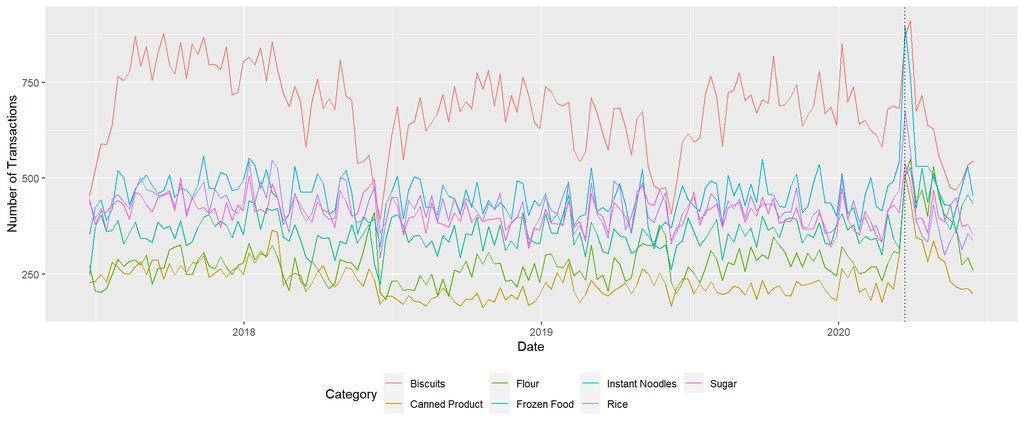

Malaysia announced their Movement Control Order (MCO) on 2020-03-18 (Wednesday). Essential goods like rice, frozen food spiked in the number of transactions for that week.

## 3. Preprocessing

## 4. Analysis

### 4.1. RFM Modelling

Assumptions:

- Weekly data represents the purchases a customer has made in that particular week. Since there is no data on receipts, we shall treat this as a single visit for computing frequency score.
- Example: Customer A who has made 10 transactions 4 weeks ago is not as frequent as Customer B who has made 1 transaction each consistently for 4 weeks.
- Approach: We group by the Panel ID and Date first to compile the transactions in 1 single receipt for that week. Then we group by Panel ID to apply RFM. The monetary is computed based on mean expenditure rather than the total sum to as the total sum is easily influenced by the frequency of the visits (collinearity issues)

### 4.2. Market Basket Analysis

## 5. Conclusion